# Week 7.1 - Rarefied hypersonic cylinder operator learning

### Central question

When a parameterized DSMC field lives on the same cylinder grid, what evidence is required before a neural operator is more useful than direct interpolation?

### Learning outcomes

1. distinguish freestream Mach from the predicted local Mach field;
2. formulate the cylinder map as an operator $G:M_\infty\mapsto q(x,y)$;
3. enforce whole-case training, validation, interpolation, and extrapolation splits;
4. explain branch, trunk, layerwise fusion, standardized targets, and weighted loss;
5. compare structured interpolation with a trained 3x96 tanh MLP; and
6. diagnose underfitting from training errors without confusing accuracy and calibration.

## Evidence and reuse contract

The compact fields are an author-released derivative of the DSMC archive used for the hypersonic-cylinder part of Roohi et al., *Physics of Fluids* **38**, 057108 (2026), [doi:10.1063/5.0334590](https://doi.org/10.1063/5.0334590). The committed NPZ contains 44,500 deterministic points from 20 cases; the 1.4 GB archive, logs, checkpoints, and 116 historical scripts are not copied.

This lab does **not** report the published full-resolution accuracy. Its default MLP is a newly trained classroom baseline, not the paper model. The optional TensorFlow builder exposes the reviewed Fusion-DeepONet topology, but full reproduction requires the original 50,000-point sampling, five trained networks, frozen protocol, and adequate compute.

```python
# FLOWMLLAB_COLAB_BOOTSTRAP_V1
from pathlib import Path as _FlowMLLabPath
import os as _flowmllab_os
import subprocess as _flowmllab_subprocess
import sys as _flowmllab_sys

if "google.colab" in _flowmllab_sys.modules or _flowmllab_os.environ.get("COLAB_RELEASE_TAG"):
    _flowmllab_root = _FlowMLLabPath("/content/FlowMLLab")
    if not (_flowmllab_root / ".git").is_dir():
        _flowmllab_subprocess.run(
            ["git", "clone", "--depth", "1",
             "https://github.com/Ehsan-Roohi/FlowMLLab.git", str(_flowmllab_root)],
            check=True,
        )
    _flowmllab_subprocess.run(
        [_flowmllab_sys.executable, "-m", "pip", "install", "-q", "-e", str(_flowmllab_root)],
        check=True,
    )
    _flowmllab_os.chdir(_flowmllab_root / "notebooks/week07_1")

from pathlib import Path
import json
import time
import numpy as np
import pandas as pd
import matplotlib.pyplot as plt
from IPython.display import display

from flowmllab.hypersonic_cylinder import (
    TARGET_NAMES,
    case_interpolation_baseline,
    casewise_split_masks,
    fit_cylinder_mlp,
    load_cylinder_teaching_data,
    relative_l2,
    validate_hypersonic_cylinder_evidence,
)

REPO_ROOT = next(
    candidate for candidate in (Path.cwd(), *Path.cwd().parents)
    if (candidate / "data/hypersonic_cylinder/manifest.json").is_file()
)
plt.rcParams.update({"font.size": 10, "axes.labelsize": 11})
print("FlowMLLab root:", REPO_ROOT)
```

```
FlowMLLab root: <FlowMLLab checkout>
```

```python
report = validate_hypersonic_cylinder_evidence(REPO_ROOT)
display(pd.DataFrame({
    "item": ["cases", "points", "targets", "paper DOI", "source archive SHA-256"],
    "value": [report["cases"], report["points"], ", ".join(report["targets"]),
              report["paper_doi"], report["source_archive_sha256"]],
}))
data = load_cylinder_teaching_data(REPO_ROOT)
```

|  | item | value |
| --- | --- | --- |
| 0 | cases | 20 |
| 1 | points | 44500 |
| 2 | targets | local_mach, temperature_ratio, pressure_ratio |
| 3 | paper DOI | 10.1063/5.0334590 |
| 4 | source archive SHA-256 | bda221759a372a2054ca4c76bde923febf0b682404b41f... |

## 1. Physics before machine learning

The control parameter $M_\infty=U_\infty/a_\infty$ is not the same quantity as the spatial target $M(x,y)$. Rarefaction is governed by $Kn=\lambda/D$; when the mean free path is not negligible relative to the cylinder diameter, continuum closure and no-slip assumptions need qualification. DSMC estimates moments of a particle distribution, so its fields also carry sampling noise.

The three source fields are local Mach, TOV (temperature), and P (pressure). The legacy NPZ names `temperature_ratio` and `pressure_ratio` are retained only for file compatibility. The source audit matches all 44,500 retained rows to archived MA/TOV/P values and verifies that the course import performs **no freestream division**. Upstream-edge medians are about 200 for TOV and 1.14 for P, not unity. An equation-of-state consistency check supports kelvin/pascal units but does not recover the producing input deck or exact freestream reference constants. Use source labels, not T/T∞ or p/p∞.

$$q(x,y;M_\infty)=\left[M(x,y),\;TOV(x,y),\;P(x,y)\right].$$

At high Mach, hypersonic Mach-number independence can make appropriately nondimensionalized fields change slowly with Mach, under fixed geometry and compatible gas, rarefaction and boundary conditions. This motivates a strong interpolation baseline, but small interpolation errors alone do not prove that limit. Verify the source scaling and operating conditions before attributing the observed sub-percent errors solely to this principle.

**Prediction prompt:** Where should the largest interpolation error occur: in the freestream, inside the shock layer, or near the surface? Record your reason before plotting.

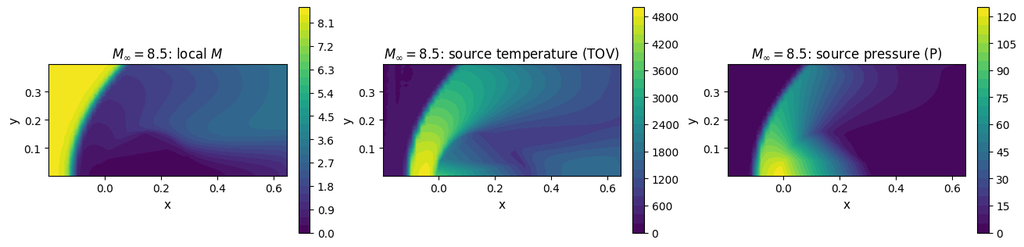

```python
case = np.isclose(data.mach_inf, 8.5)
fig, axes = plt.subplots(1, 3, figsize=(13, 3.6), constrained_layout=True)
labels = (r"local $M$", "source temperature (TOV)", "source pressure (P)")
for j, (axis, label) in enumerate(zip(axes, labels)):
    artist = axis.tricontourf(data.x[case], data.y[case], data.targets[case, j],
                              levels=28, cmap="viridis")
    axis.set(title=rf"$M_\infty=8.5$: {label}", xlabel="x", ylabel="y", aspect="equal")
    fig.colorbar(artist, ax=axis, shrink=0.82)
plt.show()
```

## 2. A split is a scientific statement

Randomly splitting points would put the same DSMC flow case in training and test sets. That tests spatial interpolation inside a known solution, not generalization to an unseen operating condition. We instead freeze whole Mach cases:

- **train:** integer $M_\infty=5,\ldots,14$;
- **validation:** 8.25, 8.75, 9.25, 9.75;
- **blind interpolation:** 5.5, 6.5, 7.5, 8.5, 9.5;
- **blind extrapolation:** 15.

Validation guided design in the recorded protocol. These historical holdouts have already been inspected and published: they are reproducibility/regression cases, not newly sealed tests. Do not tune on them and then claim fresh blind validation; a new confirmation claim needs a separate uninspected case.

```python
masks = casewise_split_masks(data.mach_inf)
split_table = []
for name, mask in masks.items():
    split_table.append({"split": name, "cases": np.unique(data.mach_inf[mask]).tolist(),
                        "points": int(mask.sum())})
display(pd.DataFrame(split_table))
assert not any(np.any(masks[a] & masks[b]) for i, a in enumerate(masks)
               for b in list(masks)[i + 1:])
```

|  | split | cases | points |
| --- | --- | --- | --- |
| 0 | train | [5.0, 6.0, 7.0, 8.0, 9.0, 10.0, 11.0, 12.0, 13... | 22250 |
| 1 | validation | [8.25, 8.75, 9.25, 9.75] | 8900 |
| 2 | interpolation | [5.5, 6.5, 7.5, 8.5, 9.5] | 11125 |
| 3 | extrapolation | [15.0] | 2225 |

## 3. Mandatory strong baseline

All cases share source-grid row identifiers, so a direct interpolation between the two bracketing training Mach fields is cheap and physically transparent. For $M_a<M_q<M_b$,

$$\hat q(M_q)=q(M_a)+\frac{M_q-M_a}{M_b-M_a}\,[q(M_b)-q(M_a)].$$

A neural operator must be compared with this baseline, not only with a trivial constant or mean field.

```python
baseline_rows = []
baseline_predictions = {}
for split_name in ("validation", "interpolation", "extrapolation"):
    mask = masks[split_name]
    prediction = case_interpolation_baseline(data, masks["train"], mask)
    baseline_predictions[split_name] = prediction
    errors = relative_l2(data.targets[mask], prediction)
    baseline_rows.append({"split": split_name, **dict(zip(TARGET_NAMES, errors))})
display(pd.DataFrame(baseline_rows).style.format({name: "{:.3%}" for name in TARGET_NAMES}))
```

|  | split | local_mach | temperature_ratio | pressure_ratio |
| --- | --- | --- | --- | --- |
| 0 | validation | 0.215% | 0.277% | 0.319% |
| 1 | interpolation | 0.398% | 0.609% | 0.779% |
| 2 | extrapolation | 0.538% | 0.877% | 0.848% |

## 4. Fusion-DeepONet anatomy

The scalar branch sees $M_\infty$; the trunk sees $(x,y)$. Four 256-unit tanh layers form each path. In the reviewed stored topology, branch features are injected into the corresponding trunk layer, dropout regularizes both paths, the final branch/trunk states are combined by an inner product, and a linear three-output head returns the standardized targets.

Only training cases may fit input and output scalers. The research workflow uses Adam, early stopping, learning-rate reduction, and five independent fits. One reviewed script weights standardized pressure error five times more than the other two components:

$$L=\operatorname{MSE}(M_s)+\operatorname{MSE}(TOV_s)+5\operatorname{MSE}(P_s),$$

where the subscript denotes training-set standardization, not physical nondimensionalization.

Because historical archive scripts disagree in several settings, this notebook records the reviewed topology and avoids presenting any one script filename as the canonical paper release.

## 5. A trained CPU MLP baseline

Train three 96-unit tanh layers on (Mach, x, y), with equal standardized-target MSE. Input/output scalers use training cases only. Select the best epoch using the four whole validation cases, with a fixed 300-epoch budget, 40-epoch patience and seed 760. No random-row validation or held-out tuning is used. This is an MLP, **not a DeepONet**. The old random-feature ridge underfit even the training fields and is no longer the required teaching model.

**Prediction prompt:** Will this trained model beat field interpolation? Why might a more complex model still be valuable for unstructured meshes, multiple geometry parameters, or unavailable bracketing cases?

```python
started = time.perf_counter()
model = fit_cylinder_mlp(
    data, masks["train"], masks["validation"], epochs=300, patience=40, seed=760
)
print(f"CPU MLP fit: {time.perf_counter() - started:.2f} s; selected epoch {model.best_epoch}")

operator_rows = []
predictions = {}
for split_name, mask in masks.items():
    mean = model.predict(data.mach_inf[mask], data.x[mask], data.y[mask])
    predictions[split_name] = mean
    errors = relative_l2(data.targets[mask], mean)
    operator_rows.append({
        "split": split_name,
        **{f"L2 {name}": value for name, value in zip(TARGET_NAMES, errors)},
    })
display(pd.DataFrame(operator_rows))
```

```
CPU MLP fit: 135.02 s; selected epoch 182
```

|  | split | L2 local_mach | L2 temperature_ratio | L2 pressure_ratio |
| --- | --- | --- | --- | --- |
| 0 | train | 0.012625 | 0.022082 | 0.018198 |
| 1 | validation | 0.012425 | 0.022196 | 0.019576 |
| 2 | interpolation | 0.015302 | 0.026975 | 0.024959 |
| 3 | extrapolation | 0.015250 | 0.033546 | 0.030903 |

## 6. Error localization and uncertainty honesty

This single MLP does not estimate uncertainty. Report training, validation and held-out errors separately; large training error signals underfitting, not evidence against neural models as a class. An optional independent multi-seed study can measure variability, but ensemble spread alone is not calibrated UQ.

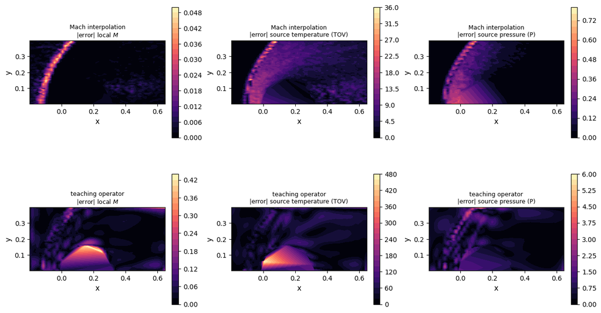

```python
mask = masks["interpolation"] & np.isclose(data.mach_inf, 8.5)
all_interpolation_indices = np.flatnonzero(masks["interpolation"])
case_positions = np.flatnonzero(np.isclose(data.mach_inf[masks["interpolation"]], 8.5))
truth = data.targets[mask]
baseline = baseline_predictions["interpolation"][case_positions]
operator = predictions["interpolation"][case_positions]

fig, axes = plt.subplots(2, 3, figsize=(12.5, 7), constrained_layout=True)
for j, label in enumerate(labels):
    for row, (title, estimate) in enumerate((("Mach interpolation", baseline),
                                             ("teaching operator", operator))):
        error = np.abs(estimate[:, j] - truth[:, j])
        artist = axes[row, j].tricontourf(data.x[mask], data.y[mask], error,
                                          levels=25, cmap="magma")
        axes[row, j].set(xlabel="x", ylabel="y", aspect="equal")
        axes[row, j].set_title(f"{title}\n|error| {label}", fontsize=9)
        fig.colorbar(artist, ax=axes[row, j], shrink=0.8)
plt.show()
```

## 7. Optional full topology - not the default runtime

If TensorFlow is available through `pip install -e ".[ml]"`, the following constructs the reviewed architecture. Keep it disabled unless you have defined a full training budget and frozen the validation protocol.

```python
RUN_FULL_NEURAL = False
if RUN_FULL_NEURAL:
    from flowmllab.hypersonic_cylinder import build_fusion_deeponet
    model = build_fusion_deeponet(latent_dim=256, hidden_layers=4, dropout_rate=0.2)
    model.summary()
else:
    print("Topology build skipped; the CPU evidence path above is complete.")
```

```
Topology build skipped; the CPU evidence path above is complete.
```

## 8. Conclusions and required submission

1. Give the three interpolation and three extrapolation relative-$L_2$ errors for both the strong baseline and the teaching operator.
2. Identify one region where each method fails and connect it to cylinder-flow physics.
3. Report training error and explain why this single fit provides no calibrated uncertainty.
4. Explain why a random point split would inflate the scientific claim.
5. Propose one change that could justify a full Fusion-DeepONet experiment.

### Claim boundary

You may claim that the compact author-released DSMC derivative and frozen split were executed. You may not claim reproduction of the paper's model accuracy, speedup, full-resolution fields, or uncertainty calibration from this notebook.